# **Rain Forecasting**

Our client, a prominent water management company based in Mumbai. They aim to revolutionize their resource management and product plannings for which they require accurate forecasting of future rainfall. They play a vital role in Mumbai's water management, striving to ensure a reliable water supply for the city's residents and industries.

Accurate rainfall forecasts are essential for planning water allocation, storage, and distribution strategies. It is crucial for their operations, to plan water allocation strategies and reservoir management more effectively. The goal of this project is to develop a machine learning model to forecast rainfall for upcoming months in Mumbai, India. By anticipating rainfall patterns, they can optimize their operations and minimize costs while ensuring a consistent water supply throughout the year.

OBJECTIVES:

- Forecast monthly rainfall to aid water resourse planning and management
- Identify pattern, trends, or anomalies in rainfall data to optimize water storage and distribution
- Mitigate the risk of water shortages or flooding

OUTPUT:

- Time Series forecast of rainfall
- Insights into rainfall trends and variabilitiy
- Provide an actionable recommendations

**Import necessary libraries and dataset**

```python
#RAINFALL FORECASTING PROJECT
#ARIES DIMAANO
#dimaanoac@gmail.com

#Import Libraries
import pandas as pd
import numpy as np
import matplotlib.pyplot as plt
from sklearn.preprocessing import MinMaxScaler
from statsmodels.tsa.arima.model import ARIMA
from statsmodels.tsa.statespace.sarimax import SARIMAX
from statsmodels.tsa.stattools import adfuller
from statsmodels.tsa.seasonal import seasonal_decompose
from statsmodels.graphics.tsaplots import plot_acf
from sklearn.metrics import mean_squared_error, mean_absolute_error
import warnings
warnings.filterwarnings("ignore")

from google.colab import drive
drive.mount('/content/drive')
import os
```

```python
#Import dataset
os.getcwd()
os.chdir('/content/drive/MyDrive/DATA SCIENCE PROJECT/Rainfall Forecast')
df = pd.read_csv('mumbai-monthly-rains.csv')
```

# **Data Preparation and analysis**

```python
df.head()
```

|  | Year | Jan | Feb | Mar | April | May | June | July | Aug | Sept | Oct | Nov | Dec | Total |
| --- | --- | --- | --- | --- | --- | --- | --- | --- | --- | --- | --- | --- | --- | --- |
| 0 | 1901 | 13.116602 | 0.000000 | 0.000000 | 3.949669 | 17.139791 | 640.714036 | 888.369692 | 545.045796 | 64.271513 | 9.871696 | 0.000000 | 0.000000 | 2182.478796 |
| 1 | 1902 | 0.000000 | 0.000000 | 0.000000 | 0.000000 | 0.355001 | 247.998782 | 408.433730 | 566.595863 | 688.913455 | 28.654092 | 0.488864 | 19.526547 | 1960.966334 |
| 2 | 1903 | 0.000000 | 0.000000 | 0.844034 | 0.000000 | 220.568740 | 370.849048 | 902.447896 | 602.420828 | 264.589816 | 157.892877 | 0.000000 | 0.000000 | 2519.613240 |
| 3 | 1904 | 0.000000 | 0.000000 | 11.381769 | 0.000000 | 0.000000 | 723.081969 | 390.886799 | 191.581927 | 85.704754 | 38.679948 | 0.000000 | 0.000000 | 1441.317168 |
| 4 | 1905 | 0.662561 | 1.713452 | 0.000000 | 0.000000 | 0.000000 | 123.870892 | 581.827975 | 167.382149 | 172.297723 | 7.365924 | 24.903575 | 0.000000 | 1080.024250 |

```python
df.info()
```

```
<class 'pandas.core.frame.DataFrame'>
RangeIndex: 121 entries, 0 to 120
Data columns (total 14 columns):
 #   Column  Non-Null Count  Dtype
---  ------  --------------  -----
 0   Year    121 non-null    int64
 1   Jan     121 non-null    float64
 2   Feb     121 non-null    float64
 3   Mar     121 non-null    float64
 4   April   121 non-null    float64
 5   May     121 non-null    float64
 6   June    121 non-null    float64
 7   July    121 non-null    float64
 8   Aug     121 non-null    float64
 9   Sept    121 non-null    float64
 10  Oct     121 non-null    float64
 11  Nov     121 non-null    float64
 12  Dec     121 non-null    float64
 13  Total   121 non-null    float64
dtypes: float64(13), int64(1)
memory usage: 13.4 KB
```

```python
#drop 'total' column
df = df.drop('Total', axis = 1)
df.head()
```

|  | Year | Jan | Feb | Mar | April | May | June | July | Aug | Sept | Oct | Nov | Dec |
| --- | --- | --- | --- | --- | --- | --- | --- | --- | --- | --- | --- | --- | --- |
| 0 | 1901 | 13.116602 | 0.000000 | 0.000000 | 3.949669 | 17.139791 | 640.714036 | 888.369692 | 545.045796 | 64.271513 | 9.871696 | 0.000000 | 0.000000 |
| 1 | 1902 | 0.000000 | 0.000000 | 0.000000 | 0.000000 | 0.355001 | 247.998782 | 408.433730 | 566.595863 | 688.913455 | 28.654092 | 0.488864 | 19.526547 |
| 2 | 1903 | 0.000000 | 0.000000 | 0.844034 | 0.000000 | 220.568740 | 370.849048 | 902.447896 | 602.420828 | 264.589816 | 157.892877 | 0.000000 | 0.000000 |
| 3 | 1904 | 0.000000 | 0.000000 | 11.381769 | 0.000000 | 0.000000 | 723.081969 | 390.886799 | 191.581927 | 85.704754 | 38.679948 | 0.000000 | 0.000000 |
| 4 | 1905 | 0.662561 | 1.713452 | 0.000000 | 0.000000 | 0.000000 | 123.870892 | 581.827975 | 167.382149 | 172.297723 | 7.365924 | 24.903575 | 0.000000 |

```python
#Check for missing values
df.isnull().sum()
```

|  | 0 |
| --- | --- |
| Year | 0 |
| Jan | 0 |
| Feb | 0 |
| Mar | 0 |
| April | 0 |
| May | 0 |
| June | 0 |
| July | 0 |
| Aug | 0 |
| Sept | 0 |
| Oct | 0 |
| Nov | 0 |
| Dec | 0 |

**dtype:** int64

```python
#Set 'Year' as the index
df = df.set_index('Year')
df.head()
```

| Year | Jan | Feb | Mar | April | May | June | July | Aug | Sept | Oct | Nov | Dec |
| --- | --- | --- | --- | --- | --- | --- | --- | --- | --- | --- | --- | --- |
| 1901 | 13.116602 | 0.000000 | 0.000000 | 3.949669 | 17.139791 | 640.714036 | 888.369692 | 545.045796 | 64.271513 | 9.871696 | 0.000000 | 0.000000 |
| 1902 | 0.000000 | 0.000000 | 0.000000 | 0.000000 | 0.355001 | 247.998782 | 408.433730 | 566.595863 | 688.913455 | 28.654092 | 0.488864 | 19.526547 |
| 1903 | 0.000000 | 0.000000 | 0.844034 | 0.000000 | 220.568740 | 370.849048 | 902.447896 | 602.420828 | 264.589816 | 157.892877 | 0.000000 | 0.000000 |
| 1904 | 0.000000 | 0.000000 | 11.381769 | 0.000000 | 0.000000 | 723.081969 | 390.886799 | 191.581927 | 85.704754 | 38.679948 | 0.000000 | 0.000000 |
| 1905 | 0.662561 | 1.713452 | 0.000000 | 0.000000 | 0.000000 | 123.870892 | 581.827975 | 167.382149 | 172.297723 | 7.365924 | 24.903575 | 0.000000 |

```python
df.describe()
```

|  | Jan | Feb | Mar | April | May | June | July | Aug | Sept | Oct | Nov | Dec |
| --- | --- | --- | --- | --- | --- | --- | --- | --- | --- | --- | --- | --- |
| count | 121.000000 | 121.000000 | 121.000000 | 121.000000 | 121.000000 | 121.000000 | 121.000000 | 121.000000 | 121.000000 | 121.000000 | 121.000000 | 121.000000 |
| mean | 1.567235 | 0.929358 | 0.869231 | 1.428458 | 18.183632 | 517.854402 | 757.407412 | 465.600818 | 312.885747 | 73.983526 | 13.849462 | 3.556428 |
| std | 6.462247 | 3.077050 | 2.890032 | 7.371307 | 48.628812 | 251.067016 | 285.836188 | 249.072915 | 205.135368 | 96.686113 | 29.689941 | 12.342390 |
| min | 0.000000 | 0.000000 | 0.000000 | 0.000000 | 0.000000 | 61.058662 | 103.209194 | 87.493370 | 36.313545 | 0.000000 | 0.000000 | 0.000000 |
| 25% | 0.000000 | 0.000000 | 0.000000 | 0.000000 | 0.000000 | 324.094617 | 540.745923 | 268.002392 | 149.584208 | 9.871696 | 0.000000 | 0.000000 |
| 50% | 0.000000 | 0.000000 | 0.000000 | 0.000000 | 0.355001 | 482.449872 | 788.403637 | 445.870342 | 269.276549 | 43.479170 | 1.066086 | 0.000000 |
| 75% | 0.000000 | 0.152298 | 0.000000 | 0.194165 | 4.208322 | 678.040770 | 942.616099 | 604.372615 | 398.645218 | 98.235161 | 9.373154 | 0.176149 |
| max | 51.348290 | 21.107118 | 18.252996 | 75.541818 | 234.392757 | 1219.518576 | 1358.833554 | 1200.956558 | 987.796660 | 552.902707 | 164.348387 | 90.044602 |

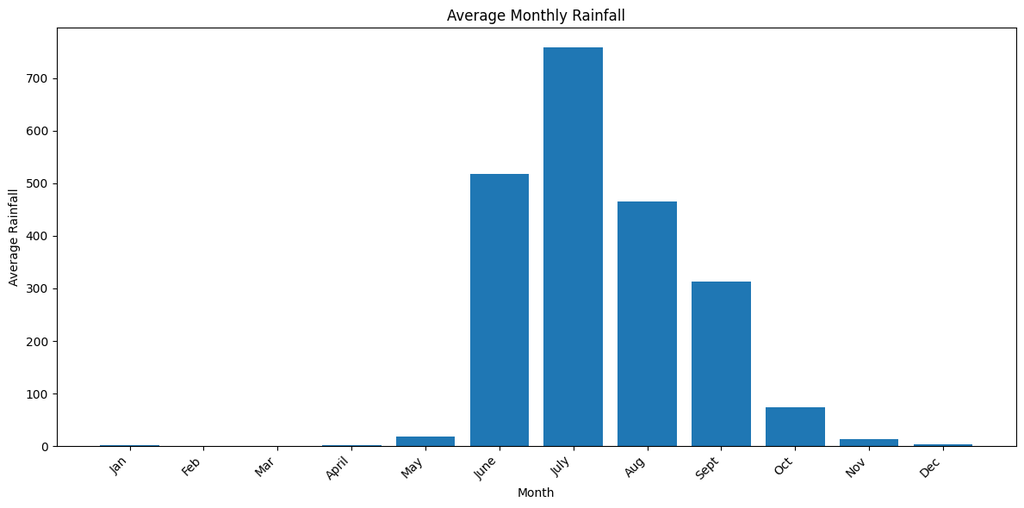

```python
#Bar Graph of averave monthly rain
#Calculate the average monthly rainfall
average_monthly_rainfall = df.mean()

#Create bar graph
plt.figure(figsize=(12, 6))
plt.bar(average_monthly_rainfall.index, average_monthly_rainfall.values)
plt.xlabel("Month")
plt.ylabel("Average Rainfall")
plt.title("Average Monthly Rainfall")
plt.xticks(rotation=45, ha='right')
plt.tight_layout()
plt.show()
```

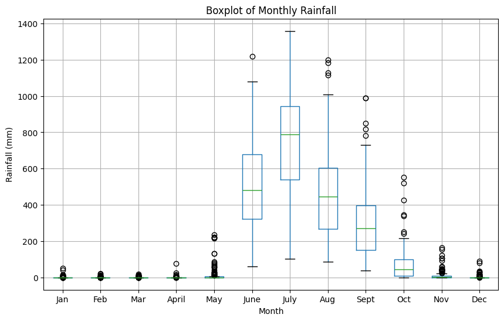

```python
#Create a boxplot for each month
plt.figure(figsize=(10, 6))
df.boxplot()
plt.title('Boxplot of Monthly Rainfall')
plt.ylabel('Rainfall (mm)')
plt.xlabel('Month')
plt.show()
```

```python
#For outliers, Cap extreme values to 99th percentile
lower_percentile = .01
upper_percentile = .99
for col in df.columns:
    lower_bound = df[col].quantile(lower_percentile)
    upper_bound = df[col].quantile(upper_percentile)
    df[col] = np.clip(df[col], lower_bound, upper_bound)
```

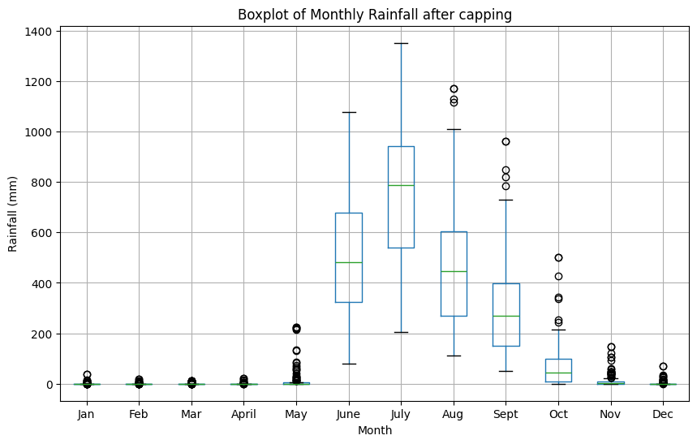

```python
#Create a boxplot for each month
plt.figure(figsize=(10, 6))
df.boxplot()
plt.title('Boxplot of Monthly Rainfall after capping')
plt.ylabel('Rainfall (mm)')
plt.xlabel('Month')
plt.show()
```

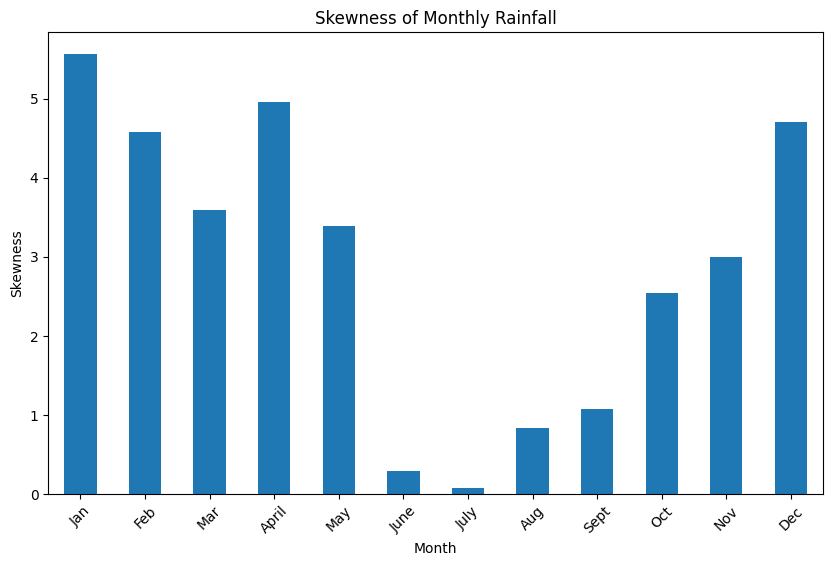

```python
# Calculate skewness for each month
skewness = df.skew()

# Create a bar plot of skewness
plt.figure(figsize=(10, 6))
skewness.plot(kind='bar')
plt.title('Skewness of Monthly Rainfall')
plt.ylabel('Skewness')
plt.xlabel('Month')
plt.xticks(rotation=45)
plt.show()
```

Transforming the data to a Linear format is necessary for:

- Time Series Analysis like ARIMA and SARIMA
- Preservation of order
- Ease of analysis
- Visualization

```python
#Transform the data to a Linear format
#Convert wide format to long format
df_long = df.stack().reset_index()
df_long.columns = ['Year', 'Month', 'Rainfall']

#Combine 'Year' and 'Month' into a single datetime column
df_long['Date'] = pd.to_datetime(df_long['Year'].astype(str) + '-' + df_long['Month'])

#Drop the 'Year' and 'Month' column
df_final = df_long[['Date', 'Rainfall']]

#Sort the date
df_final = df_final.sort_values(by='Date')

#view the finan dataset
print(df_final)
```

```
           Date    Rainfall
0    1901-01-01   13.116602
1    1901-02-01    0.000000
2    1901-03-01    0.000000
3    1901-04-01    3.949669
4    1901-05-01   17.139791
...         ...         ...
1447 2021-08-01  323.199896
1448 2021-09-01  601.247517
1449 2021-10-01   36.040432
1450 2021-11-01   25.156942
1451 2021-12-01   70.669701

[1452 rows x 2 columns]
```

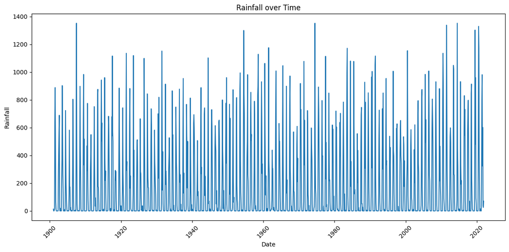

```python
#Plot the new linear data
#Assuming df_final is already created as in the provided code

plt.figure(figsize=(12, 6))
plt.plot(df_final['Date'], df_final['Rainfall'])
plt.xlabel("Date")
plt.ylabel("Rainfall")
plt.title("Rainfall over Time")
plt.xticks(rotation=45)
plt.tight_layout()
plt.show()
```

```python
#Set the year as index column
df_final = df_final.set_index('Date')
df_final.head()
```

| Date | Rainfall |
| --- | --- |
| 1901-01-01 | 13.116602 |
| 1901-02-01 | 0.000000 |
| 1901-03-01 | 0.000000 |
| 1901-04-01 | 3.949669 |
| 1901-05-01 | 17.139791 |

```python
#Data Normalization
#Apply MinMaxScaler
scaler = MinMaxScaler()
df_scaled = pd.DataFrame(scaler.fit_transform(df_final), index=df_final.index, columns=df_final.columns)
df_scaled.head()
```

| Date | Rainfall |
| --- | --- |
| 1901-01-01 | 0.009703 |
| 1901-02-01 | 0.000000 |
| 1901-03-01 | 0.000000 |
| 1901-04-01 | 0.002922 |
| 1901-05-01 | 0.012679 |

[figure not shown]

```python
#Use bar graph to show normalization
plt.figure(figsize=(12, 6))
plt.bar(df_scaled.index, df_scaled['Rainfall'])
plt.xlabel("Date")
plt.ylabel("Normalized Rainfall")
plt.title("Normalized Rainfall over Time")
plt.xticks(rotation=45)
plt.tight_layout()
plt.show()
```

# **Exploratory Data Analysis**

Before diving into model training, the following parameters needed to be checked first.

- **Stationarity** - data should be stationary for accurate forecasting
- **Seasonality** - recurring patterns that helps in forecasting and building models like SARIMA, which captures these patterns
- **Autocorrelation** - measures how the time series is related to its past values

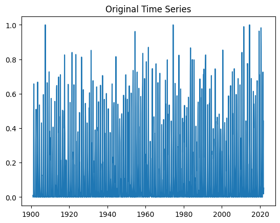

```python
#Check for stationarity
#Visual inspection
plt.plot(df_scaled)
plt.title('Original Time Series')
plt.show()
```

```python
# Perform ADF test
result = adfuller(df_scaled['Rainfall'])

# Print ADF test results
print('ADF Statistic: %f' % result[0])
print('p-value: %f' % result[1])
print('Critical Values:')
for key, value in result[4].items():
    print('\t%s: %.3f' % (key, value))

# Interpret the results
if result[1] <= 0.05:
    print("The time series is stationary.")
else:
    print("The time series is non-stationary.")
```

```
ADF Statistic: -5.583971
p-value: 0.000001
Critical Values:
	1%: -3.435
	5%: -2.864
	10%: -2.568
The time series is stationary.
```

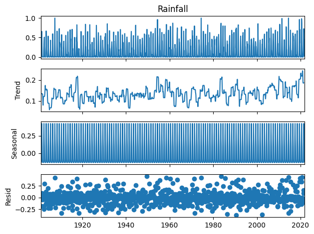

```
Date
1901-01-01   -0.132284
1901-02-01   -0.132552
1901-03-01   -0.132685
1901-04-01   -0.132744
1901-05-01   -0.120070
Name: seasonal, dtype: float64
```

```python
#Check for seasonality
result = seasonal_decompose(df_scaled['Rainfall'], model='additive', period=12) # or 'multiplicative'

# Plot the decomposition
result.plot()
plt.show()

# Access the individual components
trend = result.trend
seasonal = result.seasonal
residual = result.resid


print(seasonal.head())
```

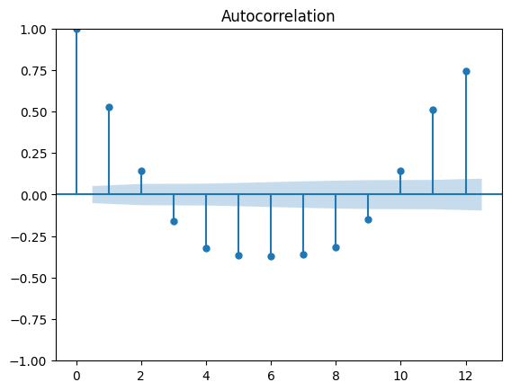

[output not shown]

[output not shown]

```python
#Plot autocorrelation
plot_acf(df_scaled['Rainfall'], lags=12)
plt.show('Autocorrelation Plot')
plt.show
```

# **Time Based Splitting**

Split the data to 80% Training data and 20% Testing data

```python
#Define the train-test split ratio
train_size = int(len(df_scaled)*.80)

#split the data
train_data = df_scaled[:train_size] #First 80% of the data
test_data = df_scaled[train_size:] #Last 20% of the data

#Print sizes
print("Train Data Size:", len(train_data))
print("Test Data Size:", len(test_data))
```

```
Train Data Size: 1161
Test Data Size: 291
```

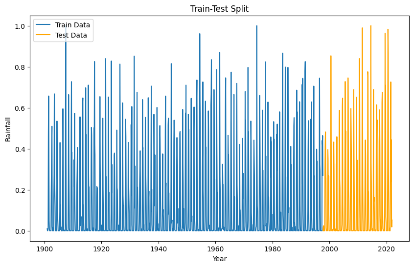

```python
#Plotting the train-test split
plt.figure(figsize=(10, 6))
plt.plot(train_data, label='Train Data')
plt.plot(test_data, label='Test Data', color='orange')
plt.title(f'Train-Test Split')
plt.xlabel('Year')
plt.ylabel('Rainfall')
plt.legend()
plt.show()
```

# **Model Training**

This model training involves using historical data to estimate the parameters of a time-series model(ARIMA and SARIMA) that best capture the underlying patterns, like trends, seasonality and residuals.

**ARIMA Model**

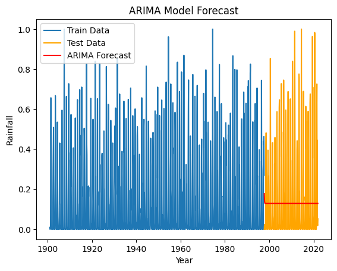

```python
#ARIMA

p, d, q = 1, 0, 1
model_arima = ARIMA(train_data, order=(p, d, q))
result_arima = model_arima.fit()

#Forecast on test data
forecast_arima = result_arima.forecast(steps=len(test_data))

#plotting
plt.plot(train_data, label='Train Data')
plt.plot(test_data, label='Test Data', color = 'orange')
plt.plot(test_data.index, forecast_arima, label='ARIMA Forecast', color='red')
plt.title('ARIMA Model Forecast')
plt.xlabel('Year')
plt.ylabel('Rainfall')
plt.legend()
plt.show()
```

**SARIMA Model**

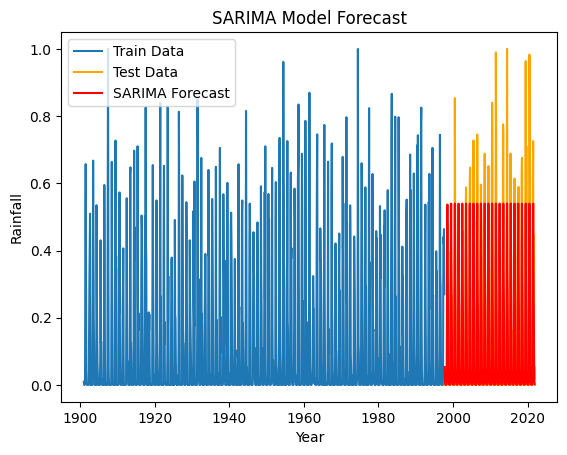

```python
#SARIMA
p, d, q = 1, 0, 1
P, D, Q, s = 1, 1, 1, 12
model_sarima = SARIMAX(train_data, order=(p, d, q), seasonal_order=(P, D, Q, s))
result_sarima = model_sarima.fit()

#Forecast on test data
forecast_sarima = result_sarima.forecast(steps=len(test_data))

#plotting
plt.plot(train_data, label='Train Data')
plt.plot(test_data, label='Test Data', color = 'orange')
plt.plot(test_data.index, forecast_sarima, label='SARIMA Forecast', color='red')
plt.title('SARIMA Model Forecast')
plt.xlabel('Year')
plt.ylabel('Rainfall')
plt.legend()
plt.show()
```

**Evaluate SARIMA and ARIMA Performance**

```python
#Calculate RMSE
rmse_arima = np.sqrt(mean_squared_error(test_data, forecast_arima))
rmse_sarima = np.sqrt(mean_squared_error(test_data, forecast_sarima))


#Calculate MAE
mae_arima = mean_absolute_error(test_data, forecast_arima)
mae_sarima = mean_absolute_error(test_data, forecast_sarima)

print(f"RMSE for ARIMA model {rmse_arima}")
print(f"MAE for ARIMA model: {mae_arima}")
print(" ")
print(f"RMSE for SARIMA model {rmse_sarima}")
print(f"MAE for SARIMA model: {mae_sarima}")
```

```
RMSE for ARIMA model 0.24031609276972313
MAE for ARIMA model: 0.18150677356837244

RMSE for SARIMA model 0.11801853021473611
MAE for SARIMA model: 0.0601108318794292
```

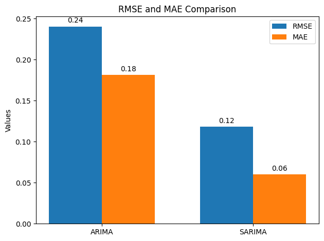

```python
#Data for the bar graph
models = ['ARIMA', 'SARIMA']
rmse_values = [rmse_arima, rmse_sarima]
mae_values = [mae_arima, mae_sarima]

#Create the bar graph
bar_width = 0.35
x_pos = np.arange(len(models))

fig, ax = plt.subplots()
rects1 = ax.bar(x_pos - bar_width/2, rmse_values, bar_width, label='RMSE')
rects2 = ax.bar(x_pos + bar_width/2, mae_values, bar_width, label='MAE')

#Add labels and title
ax.set_ylabel('Values')
ax.set_title('RMSE and MAE Comparison')
ax.set_xticks(x_pos)
ax.set_xticklabels(models)
ax.legend()

#Add value labels on top of the bars
def autolabel(rects):
    for rect in rects:
        height = rect.get_height()
        ax.annotate(f'{height:.2f}',
                    xy=(rect.get_x() + rect.get_width() / 2, height),
                    xytext=(0, 3),
                    textcoords="offset points",
                    ha='center', va='bottom')

autolabel(rects1)
autolabel(rects2)

fig.tight_layout()
plt.show()
```

### **Model Selection Conclusion**

The **SARIMA MODEL** is significantly better than ARIMA model based on both **Root-means-squared-error** and **Mean-absolute-error**. This is result is expected because SARIMA incorporates seasonality, which is crucial component of data.

Now that the final model to used is determined, the next step will be:

- Evaluate model residuals
- Make future predictions
- Save and export results
- Share actionable recommendation

# **Evaluate Residuals**

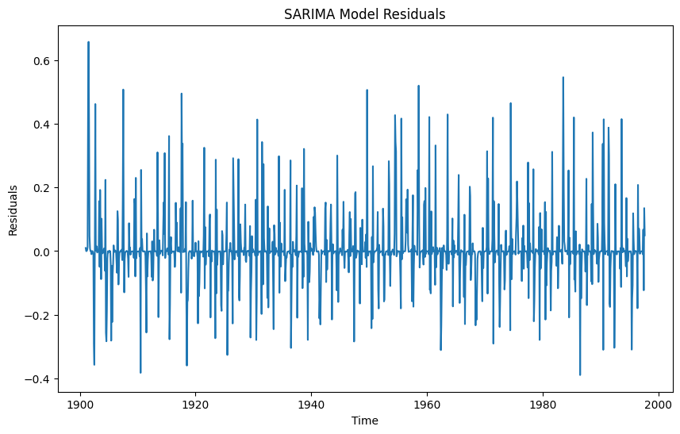

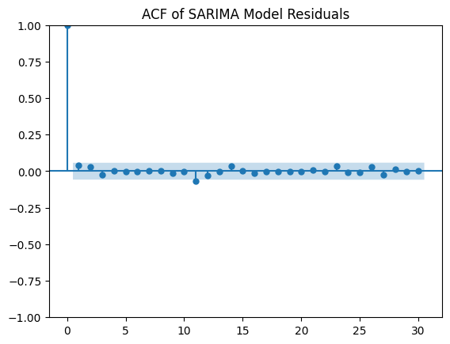

```python
# Evaluate SARIMA model residuals
residuals_sarima = result_sarima.resid

# Plot residuals
plt.figure(figsize=(10, 6))
plt.plot(residuals_sarima)
plt.title('SARIMA Model Residuals')
plt.xlabel('Time')
plt.ylabel('Residuals')
plt.show()

# Plot ACF of residuals
plot_acf(residuals_sarima, lags=30) # Adjust lags as needed
plt.title('ACF of SARIMA Model Residuals')
plt.show()
```

The residuals are centered around zero, indicating that the model captures the trend and seasonality well. There's no noticeable pattern in the residuals, suggesting that the remaining variations are random or white noise. And, the residual variance seems consistent overtime. The residuals exhibit randomness, confirming that the SARIMA model is well suited.

```python
#Perform ADF test on residuals
result_residuals = adfuller(residuals_sarima)
print('ADF Statistic for Residuals: %f' % result_residuals[0])
print('p-value for Residuals: %f' % result_residuals[1])

#Check for stationarity of the residuals
if result_residuals[1] <= 0.05:
    print("The residuals appear to be stationary.")
else:
    print("The residuals may not be stationary. Consider further analysis or model adjustments.")
```

```
ADF Statistic for Residuals: -32.592239
p-value for Residuals: 0.000000
The residuals appear to be stationary.
```

# **Future Prediction**

```python
#Future Predictions (60 months)
future_steps = 60
future_forecast = result_sarima.get_forecast(steps=future_steps)
future_forecast_values = future_forecast.predicted_mean

#Confidence intervals
confidence_intervals = future_forecast.conf_int()

#Inverse transform the scaled data back to the original scale
future_forecast_original_scale = scaler.inverse_transform(np.array(future_forecast_values).reshape(-1, 1))
lower_bound_original_scale = scaler.inverse_transform(np.array(confidence_intervals['lower Rainfall']).reshape(-1, 1))
upper_bound_original_scale = scaler.inverse_transform(np.array(confidence_intervals['upper Rainfall']).reshape(-1, 1))


#Create a date range for the future predictions
last_date = df_final.index[-1]
future_dates = pd.date_range(start=last_date + pd.DateOffset(months=1), periods=future_steps, freq='MS')

#Create a DataFrame for the future predictions
future_predictions_df = pd.DataFrame({
    'Date': future_dates,
    'Rainfall (mm)': future_forecast_original_scale.flatten(),
    'Lower Bound (mm)': lower_bound_original_scale.flatten(),
    'Upper Bound (mm)': upper_bound_original_scale.flatten()
})

future_predictions_df = future_predictions_df.set_index('Date')
```

```python
#Print the future predictions
print(future_predictions_df)
```

```
            Rainfall (mm)  Lower Bound (mm)  Upper Bound (mm)
Date
2022-01-01      72.038157       -210.241637        354.317950
2022-02-01      13.600614       -268.687880        295.889108
2022-03-01       1.866951       -280.421636        284.155537
2022-04-01       1.679995       -280.593617        283.953607
2022-05-01       1.012241       -281.261371        283.285853
2022-06-01       0.617681       -281.655932        282.891293
2022-07-01       1.052041       -281.221571        283.325654
2022-08-01      13.174701       -269.098911        295.448313
2022-09-01     512.623545        230.349933        794.897157
2022-10-01     725.523981        443.250368       1007.797593
2022-11-01     450.048474        167.774861        732.322086
2022-12-01     299.486576         17.212964        581.760188
2023-01-01      71.297714       -211.149413        353.744840
2023-02-01      13.960976       -268.486162        296.408113
2023-03-01       1.920241       -280.526896        284.367377
2023-04-01       1.722323       -280.709096        284.153742
2023-05-01       1.037378       -281.394041        283.468797
2023-06-01       0.632981       -281.798439        283.064400
2023-07-01       1.071735       -281.359684        283.503154
2023-08-01      13.500873       -268.930547        295.932292
2023-09-01     510.595747        228.164328        793.027166
2023-10-01     729.355325        446.923906       1011.786744
2023-11-01     445.664281        163.232862        728.095700
2023-12-01     297.863556         15.432137        580.294975
2024-01-01      71.279382       -211.169663        353.728427
2024-02-01      13.969897       -268.479149        296.418944
2024-03-01       1.921560       -280.527485        284.370605
2024-04-01       1.723371       -280.709938        284.156680
2024-05-01       1.038000       -281.395309        283.471309
2024-06-01       0.633359       -281.799950        283.066669
2024-07-01       1.072223       -281.361086        283.505532
2024-08-01      13.508948       -268.924361        295.942257
2024-09-01     510.545544        228.112235        792.978853
2024-10-01     729.450179        447.016870       1011.883489
2024-11-01     445.555740        163.122431        727.989049
2024-12-01     297.823374         15.390065        580.256683
2025-01-01      71.278928       -211.170191        353.728048
2025-02-01      13.970118       -268.479002        296.419238
2025-03-01       1.921593       -280.527526        284.370712
2025-04-01       1.723397       -280.709986        284.156779
2025-05-01       1.038016       -281.395367        283.471398
2025-06-01       0.633369       -281.800014        283.066751
2025-07-01       1.072235       -281.361148        283.505617
2025-08-01      13.509148       -268.924235        295.942530
2025-09-01     510.544301        228.110919        792.977684
2025-10-01     729.452528        447.019145       1011.885910
2025-11-01     445.553052        163.119670        727.986435
2025-12-01     297.822380         15.388997        580.255762
2026-01-01      71.278917       -211.170232        353.728066
2026-02-01      13.970124       -268.479026        296.419274
2026-03-01       1.921594       -280.527555        284.370742
2026-04-01       1.723397       -280.710015        284.156810
2026-05-01       1.038016       -281.395396        283.471428
2026-06-01       0.633369       -281.800043        283.066781
2026-07-01       1.072235       -281.361177        283.505647
2026-08-01      13.509153       -268.924260        295.942565
2026-09-01     510.544270        228.110858        792.977683
2026-10-01     729.452586        447.019174       1011.885998
2026-11-01     445.552986        163.119574        727.986398
2026-12-01     297.822355         15.388943        580.255767
```

Since, negative measurement in Rainfall is unrealistic, Set the limit to zero (0).

```python
#Set the Lower Bound column to zero if it's less that zero
future_predictions_df.loc[future_predictions_df['Lower Bound (mm)'] < 0, 'Lower Bound (mm)'] = 0
```

[output not shown]

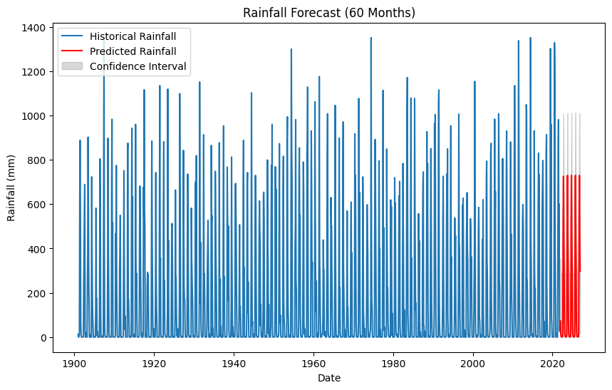

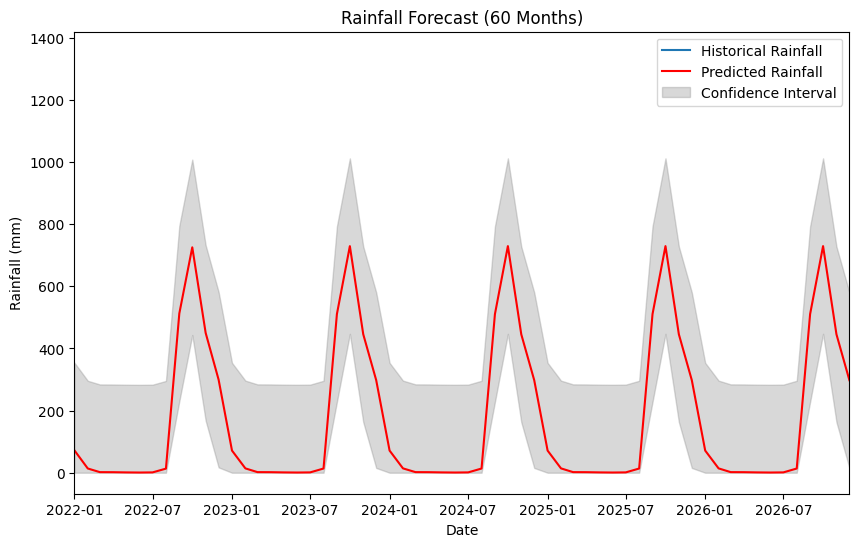

```python
#Print or visualize the future predictions
print(future_predictions_df)

plt.figure(figsize=(10, 6))
plt.plot(df_final['Rainfall'], label='Historical Rainfall')
plt.plot(future_predictions_df['Rainfall (mm)'], label='Predicted Rainfall', color='red')
plt.fill_between(future_predictions_df.index, future_predictions_df['Lower Bound (mm)'], future_predictions_df['Upper Bound (mm)'], color='gray', alpha=0.3, label='Confidence Interval')
plt.title('Rainfall Forecast (60 Months)')
plt.xlabel('Date')
plt.ylabel('Rainfall (mm)')
plt.legend()
plt.show()

plt.figure(figsize=(10, 6))
plt.plot(df_final['Rainfall'], label='Historical Rainfall')
plt.plot(future_predictions_df['Rainfall (mm)'], label='Predicted Rainfall', color='red')
plt.fill_between(future_predictions_df.index, future_predictions_df['Lower Bound (mm)'], future_predictions_df['Upper Bound (mm)'], color='gray', alpha=0.3, label='Confidence Interval')
plt.title('Rainfall Forecast (60 Months)')
plt.xlabel('Date')
plt.xlim(future_predictions_df.index[0], future_predictions_df.index[-1])
plt.ylabel('Rainfall (mm)')
plt.legend()
plt.show()
```

# **Yearly Prediction Visualization**

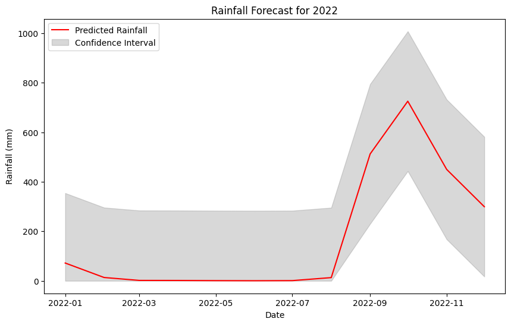

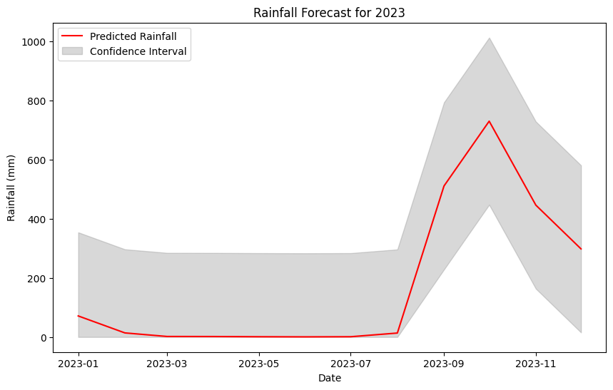

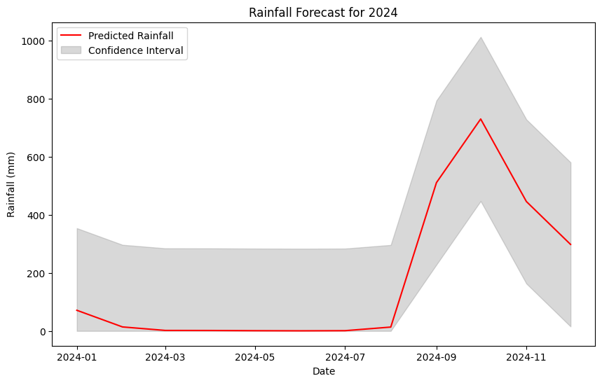

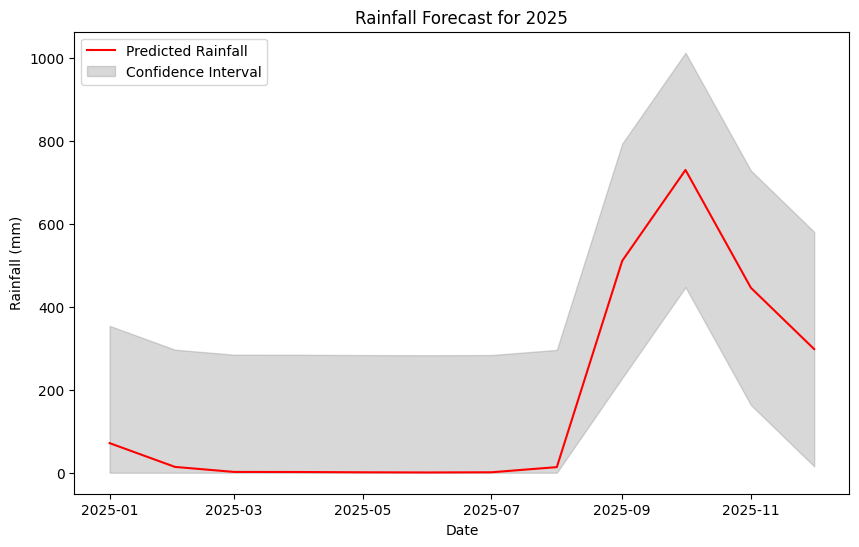

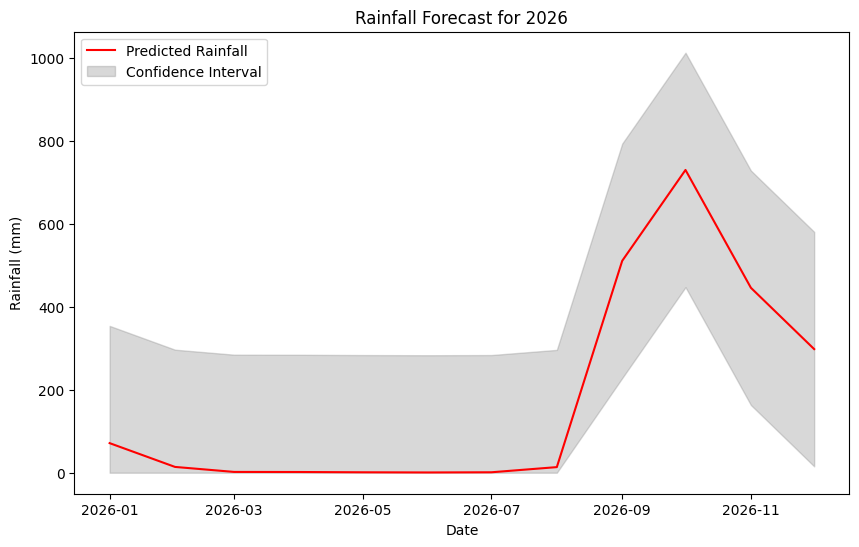

```python
#Yearly Rainfall Graph
for year in future_predictions_df.index.year.unique():
  #Filter data for the current year
  year_data = future_predictions_df[future_predictions_df.index.year == year]

  plt.figure(figsize=(10, 6))
  plt.plot(year_data['Rainfall (mm)'], label='Predicted Rainfall', color='red')
  plt.fill_between(year_data.index, year_data['Lower Bound (mm)'], year_data['Upper Bound (mm)'], color='gray', alpha=0.3, label='Confidence Interval')
  plt.title(f'Rainfall Forecast for {year}')
  plt.xlabel('Date')
  plt.ylabel('Rainfall (mm)')
  plt.legend()
  plt.show()
```